# Economy and institutions

Session 1

Luis F. Gómez L.

luis.gomezl@unimilitar.edu.co

Distance Learning Faculty

3 February, 2026

# Please Read Me

- Check the message **Welcome greeting** published in Announcements forum.
- Dear student please edit your profile uploading a photo where your face is clearly visible.
- If you want to participate, please fill out the following survey: **Primer corte 30% > Learning Activities > Tu opinión sobre la economía colombiana**
- This presentation is based on (Cardenas, 2020, Chapter 4)
- **Purpose**
  - Analyze the role of institutions in the economy

# Definition of institutions

- **“Institutions are the rules of the game in a society or, more formally, are the humanly devised constraints that shape human interaction”** (North, 1990, p. 3)
- Institutions can be informal or formal (North, 1991)
  - **Informal**: sanctions, taboos, customs, traditions, and codes of conduct
  - **Formal**: constitutions, laws, property right

# Measuring formal institutions

- Governance
  - Set of traditions and institutions by which authority in a country is exercised where it includes (Kaufmann et al., 2011, p. 222):
    - The process by which governments are selected, monitored and replaced
    - The capacity of the government to effectively formulate and implement sound policies
    - The respect of citizens and the state for the institutions that govern economic and social interactions among them

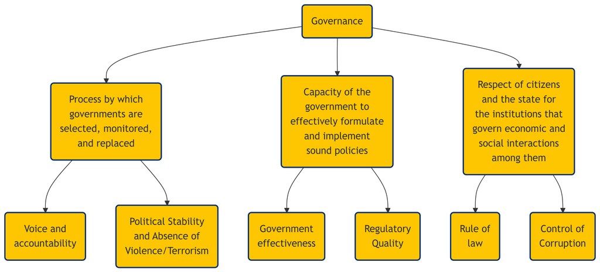

Figure 1: Governance dimensions (Kaufmann et al., 2011, p. 223)

- Where can I find data?
  - Worldwide Governance Indicators (WGI) - WorldBank
    - https://databank.worldbank.org/source/worldwide-governance-indicators
- What is the methodology?
  - https://www.worldbank.org/en/publication/worldwide-governance-indicators > Documentation

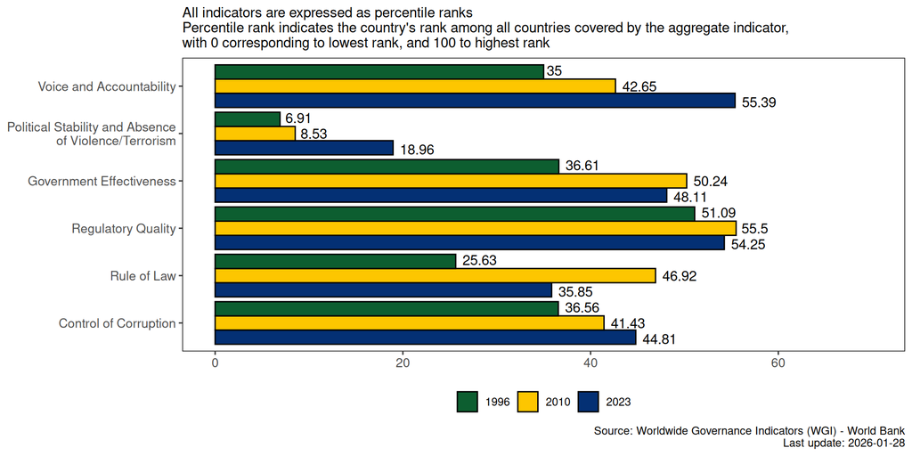

Figure 2: Governance dimensions for Colombia

# Crime

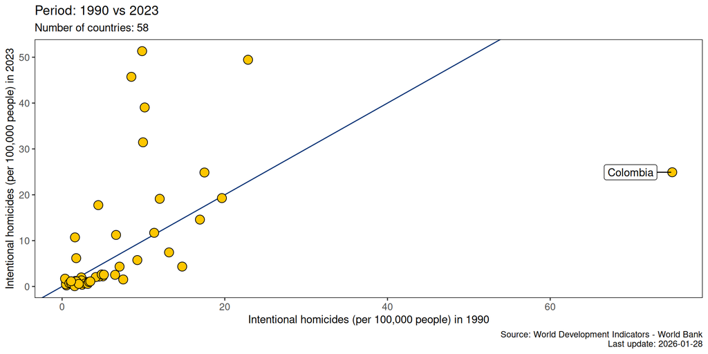

Figure 3: Intentional homicides (per 100,000 people)

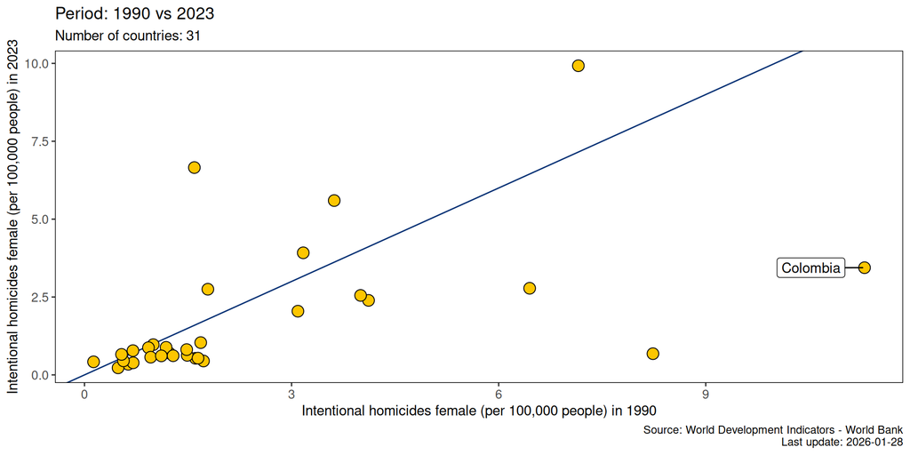

Figure 4: Intentional homicides, female (per 100,000 female)

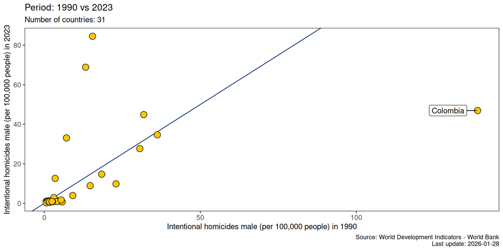

Figure 5: Intentional homicides, male (per 100,000 male)

- In Colombia, the **Observatorio de Derechos Humanos y Defensa Nacional** is responsible for producing, consolidating, and analyzing statistical data related to defense and security.
  - For detailed information on definitions and indicators regarding this topic, please refer to (Defensa Nacional, 2024).

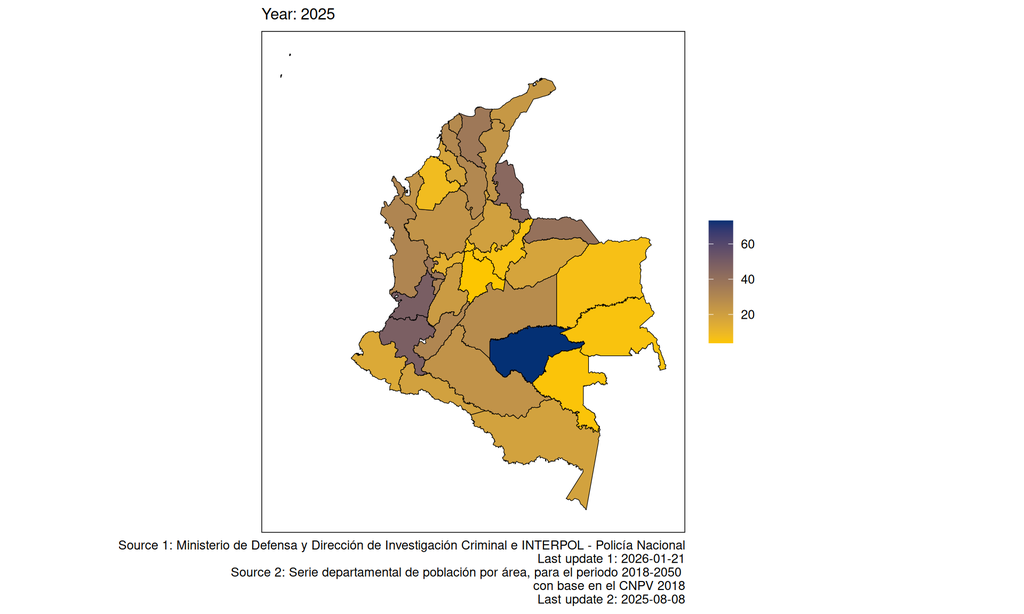

Figure 6: Intentional homicides (per 100,000 people) by department

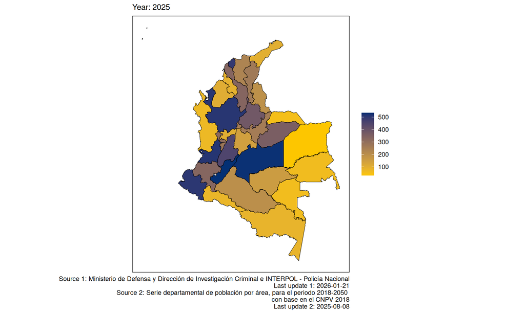

Figure 7: Theft from person[^1] (per 100,000 people) by department

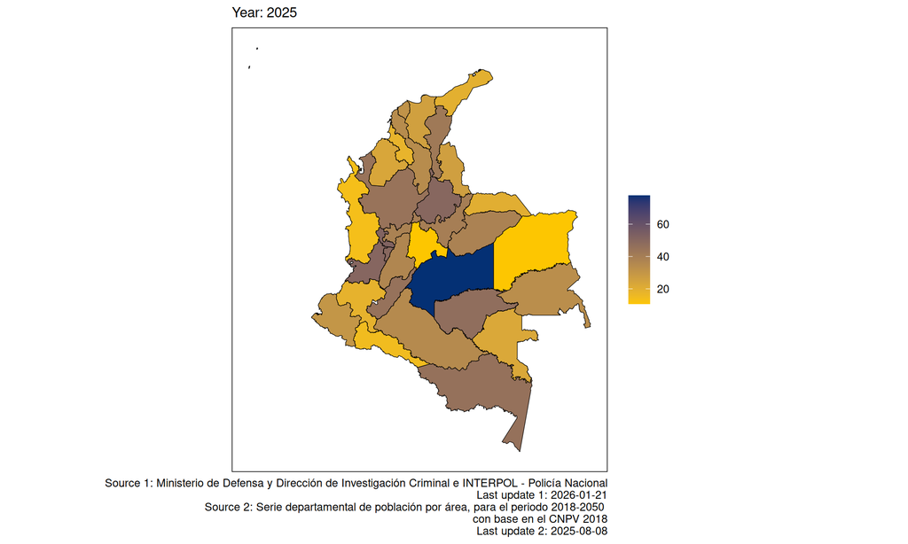

Figure 8: Theft from commercial establishments[^2] (per 100,000 people) by department

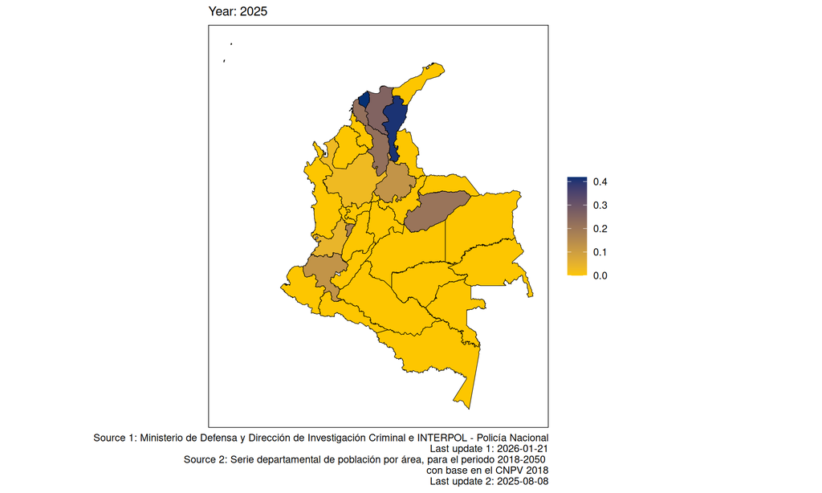

Figure 9: Robbery of Financial Institutions[^3] (per 100,000 people) by department

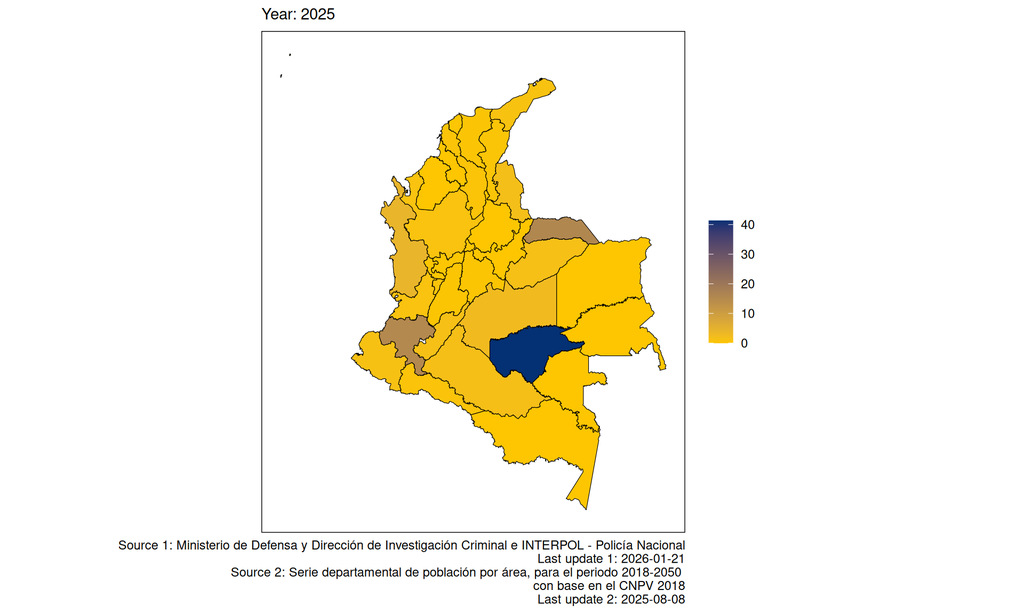

Figure 10: Kidnapping (per 100,000 people) by department

# Acknowledgments

- To my family that supports me
- To the taxpayers of Colombia and the [**UMNG students**](https://www.umng.edu.co/estudiante) who pay my salary
- To the [**Business Science**](https://www.business-science.io/) and [**R4DS Online Learning**](https://www.rfordatasci.com/) communities where I learn [**R**](https://www.r-project.org/about.html) and [**$\pi$-thon**](https://www.python.org/about/)
- To the [**R Core Team**](https://www.r-project.org/contributors.html), the creators of [**RStudio IDE**](https://posit.co/download/rstudio-desktop/), [**Positron**](https://positron.posit.co/), [**Quarto**](https://quarto.org/) and the authors and maintainers of the packages [**tidyverse**](https://CRAN.R-project.org/package=tidyverse), [**wbstats**](https://CRAN.R-project.org/package=wbstats), [**ggrepel**](https://CRAN.R-project.org/package=ggrepel), [**janitor**](https://CRAN.R-project.org/package=janitor), [**sf**](https://CRAN.R-project.org/package=sf), [**readxl**](https://CRAN.R-project.org/package=readxl) and [**tinytex**](https://CRAN.R-project.org/package=tinytex) for allowing me to access these tools without paying for a license

# References

Cardenas, M. (2020). *Introducción a la Economía Colombiana* (4th ed.). Alfaomega.

Defensa Nacional, M. de. (2024). *Metodología para la consolidación de la Información Estadística del Sector Defensa y Seguridad Nacional*. https://www.mindefensa.gov.co/defensa-y-seguridad/datos-y-cifras/documentos-metodologicos

Kaufmann, D., Kraay, A., & Mastruzzi, M. (2011). The Worldwide Governance Indicators: Methodology and Analytical Issues. *Hague Journal on the Rule of Law*, *3*(02), 220–246. https://doi.org/10.1017/S1876404511200046

North, D. C. (1990). *Institutions, institutional change, and economic performance*. Cambridge University Press.

North, D. C. (1991). Institutions. *Journal of Economic Perspectives*, *5*(1), 97–112. https://doi.org/10.1257/jep.5.1.97

## Footnotes

[^1]: *Hurto a personas* in spanish
[^2]: *Hurto a comercio* in spanish
[^3]: *Hurto a entidades financieras* in spanish